# Evolution of the Center in the NBA

Ethan Liu

2026-06-16

## Introduction

The NBA has undergone a dramatic stylistic transformation over the past four decades. Nowhere is this more visible than at the center position. The centers of the 1980s and 1990s — physical, interior-oriented players who dominated through rebounding and post scoring — look almost nothing like the stretch bigs and floor spacers who populate rosters today. Where Patrick Ewing and Hakeem Olajuwon defined success through proximity to the basket, modern centers like Nikola Jokić and Karl-Anthony Towns are expected to facilitate offense from the perimeter and knock down three-pointers.

This raises a natural question: is the change in the center position real and quantifiable, or is it more of a narrative than a statistical reality? And if it is real, how many distinct types of centers have existed across this era, and where is the position headed?

This analysis uses season-level statistics from Basketball Reference to examine how the center position has evolved since 1980, using ANOVA to test for differences across eras, principal component analysis and hierarchical clustering to identify distinct center archetypes, and ARIMA time series forecasting to project where the position is heading.

## Data

Data was sourced from [Basketball Reference](https://www.basketball-reference.com/), containing season averages for every NBA player since 1950. The dataset was filtered to include only players whose primary position was center (C, C-PF, PF-C, or SF-C), seasons from 1980 onward (coinciding with the introduction of the three-point line), and players who appeared in at least 40 games in a season to exclude small sample sizes.

For players who were traded mid-season, only their combined `TOT` row was retained to avoid double-counting. Shooting percentage columns with missing values (typically due to zero attempts) were imputed with zero.

```r
library(dplyr)
library(ggplot2)
library(factoextra)
library(FactoMineR)
library(cluster)
library(forecast)

# Load data — place season_stats.csv in the same directory as this file
data <- read.csv("season_stats.csv")

# Filter to centers and forwards who primarily play center
centers_raw <- data %>%
  filter(Pos %in% c("C", "C-PF", "PF-C", "SF-C")) %>%
  filter(Year >= 1980)

# For traded players, keep only the TOT (combined) row
centers_clean <- centers_raw %>%
  group_by(Player, Year) %>%
  filter(Tm == "TOT" | n() == 1) %>%
  ungroup()

# Minimum games played filter
centers_clean <- centers_clean %>% filter(G >= 40)

# Impute missing shooting percentages with zero (no attempts)
centers_clean <- centers_clean %>%
  mutate(
    X3P.  = ifelse(is.na(X3P.),  0, X3P.),
    X2P.  = ifelse(is.na(X2P.),  0, X2P.),
    FG.   = ifelse(is.na(FG.),   0, FG.),
    eFG.  = ifelse(is.na(eFG.),  0, eFG.),
    FT.   = ifelse(is.na(FT.),   0, FT.),
    TS.   = ifelse(is.na(TS.),   0, TS.),
    X3PAr = ifelse(is.na(X3PAr), 0, X3PAr),
    FTr   = ifelse(is.na(FTr),   0, FTr),
    TOV.  = ifelse(is.na(TOV.),  0, TOV.)
  )

# Assign decade labels
centers_clean <- centers_clean %>%
  mutate(Decade = case_when(
    Year < 1990 ~ "1980s",
    Year < 2000 ~ "1990s",
    Year < 2010 ~ "2000s",
    TRUE        ~ "2010s+"
  ))

# Derive assists per 36 minutes
centers_clean <- centers_clean %>%
  mutate(AP36 = (AST / MP) * 36)

cat("Total player-seasons:", nrow(centers_clean), "\n")
```

```
## Total player-seasons: 2713
```

```r
cat("Years covered:", min(centers_clean$Year), "to", max(centers_clean$Year), "\n")
```

```
## Years covered: 1980 to 2024
```

## Era Comparisons

Before turning to multivariate methods, it is worth asking whether centers from different eras are meaningfully different on individual statistics. The following analyses use one-way ANOVA to test for differences in means across decades, with Tukey HSD post-hoc comparisons to identify which specific eras differ.

### Three-Point Attempts

The three-point line was introduced to the NBA in 1979, but centers largely ignored it for decades. The question is whether the current era represents a genuine shift in how centers are used offensively from the perimeter.

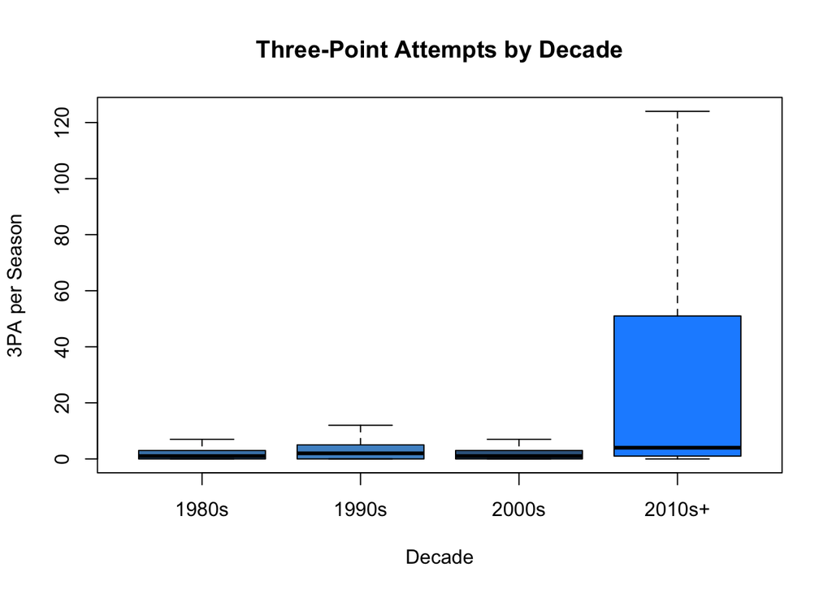

```r
boxplot(X3PA ~ Decade, data = centers_clean,
        main = "Three-Point Attempts by Decade",
        xlab = "Decade", ylab = "3PA per Season",
        col = c("steelblue", "steelblue3", "steelblue4", "dodgerblue"),
        outline = FALSE)
```

```r
anova_3pa <- aov(X3PA ~ Decade, data = centers_clean)
summary(anova_3pa)
```

```
##               Df  Sum Sq Mean Sq F value Pr(>F)
## Decade         3  979891  326630   99.96 <2e-16 ***
## Residuals   2709 8851707    3268
## ---
## Signif. codes:  0 '***' 0.001 '**' 0.01 '*' 0.05 '.' 0.1 ' ' 1
```

```r
TukeyHSD(anova_3pa)
```

```
##   Tukey multiple comparisons of means
##     95% family-wise confidence level
##
## Fit: aov(formula = X3PA ~ Decade, data = centers_clean)
##
## $Decade
##                   diff       lwr      upr     p adj
## 1990s-1980s   5.187901 -3.751508 14.12731 0.4425459
## 2000s-1980s   7.057780 -1.538471 15.65403 0.1499295
## 2010s+-1980s 43.832117 35.813194 51.85104 0.0000000
## 2000s-1990s   1.869878 -6.513431 10.25319 0.9400418
## 2010s+-1990s 38.644216 30.853999 46.43443 0.0000000
## 2010s+-2000s 36.774338 29.380423 44.16825 0.0000000
```

Tukey HSD confirms that the 2010s+ era is significantly different from all prior decades in three-point attempts, while differences among the 1980s, 1990s, and 2000s are comparatively modest. The shift is concentrated in the most recent era.

### Assists Per 36 Minutes

The modern center is expected to be a playmaker, not just a finisher. Assists per 36 minutes normalizes for playing time and allows fair comparison across eras.

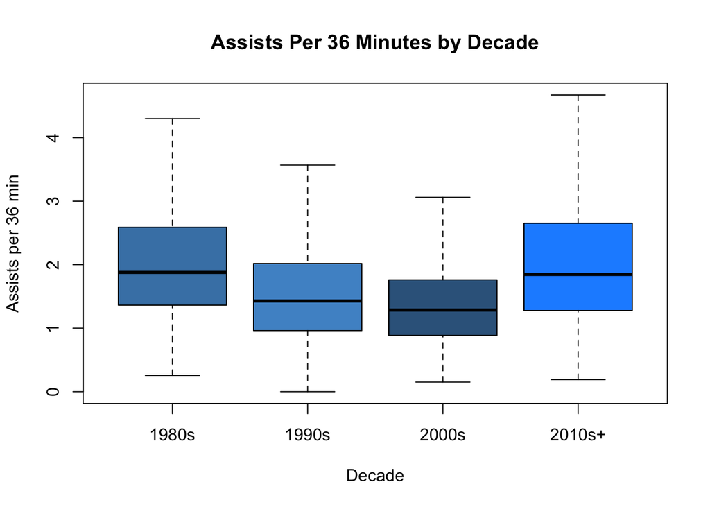

```r
boxplot(AP36 ~ Decade, data = centers_clean,
        main = "Assists Per 36 Minutes by Decade",
        xlab = "Decade", ylab = "Assists per 36 min",
        col = c("steelblue", "steelblue3", "steelblue4", "dodgerblue"),
        outline = FALSE)
```

```r
anova_ast <- aov(AP36 ~ Decade, data = centers_clean)
summary(anova_ast)
```

```
##               Df Sum Sq Mean Sq F value Pr(>F)
## Decade         3  256.2   85.39    80.6 <2e-16 ***
## Residuals   2709 2870.0    1.06
## ---
## Signif. codes:  0 '***' 0.001 '**' 0.01 '*' 0.05 '.' 0.1 ' ' 1
```

```r
TukeyHSD(anova_ast)
```

```
##   Tukey multiple comparisons of means
##     95% family-wise confidence level
##
## Fit: aov(formula = AP36 ~ Decade, data = centers_clean)
##
## $Decade
##                     diff         lwr         upr     p adj
## 1990s-1980s  -0.47362060 -0.63458663 -0.31265458 0.0000000
## 2000s-1980s  -0.64581905 -0.80060606 -0.49103205 0.0000000
## 2010s+-1980s  0.05759865 -0.08679279  0.20199009 0.7345367
## 2000s-1990s  -0.17219845 -0.32315117 -0.02124573 0.0178293
## 2010s+-1990s  0.53121925  0.39094596  0.67149255 0.0000000
## 2010s+-2000s  0.70341770  0.57028036  0.83655505 0.0000000
```

### Defensive Win Shares

If offensive responsibilities have expanded, has defensive production changed correspondingly? Defensive Win Shares captures a player’s estimated contribution to team wins through defense.

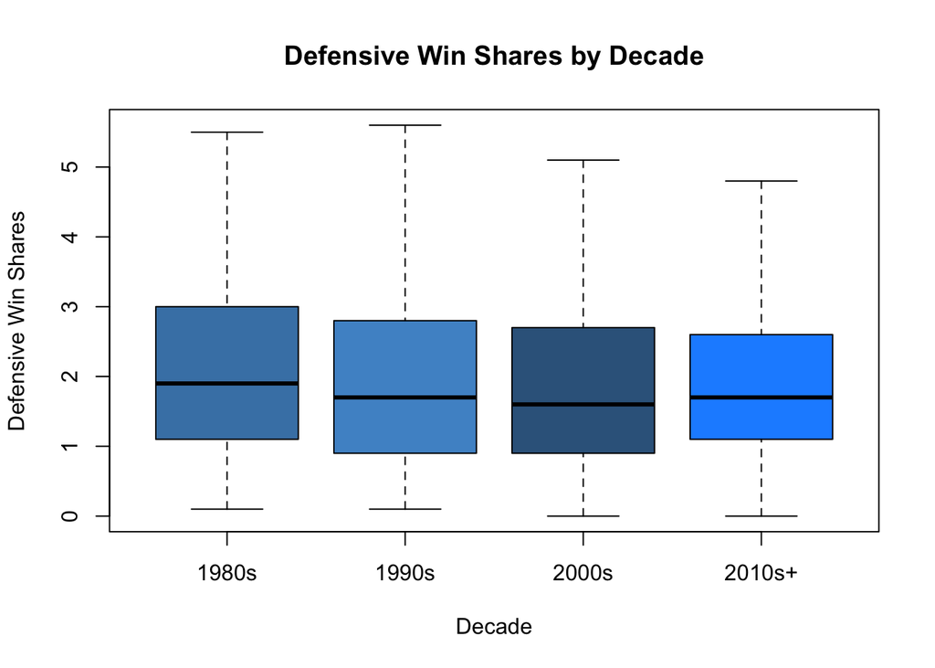

```r
boxplot(DWS ~ Decade, data = centers_clean,
        main = "Defensive Win Shares by Decade",
        xlab = "Decade", ylab = "Defensive Win Shares",
        col = c("steelblue", "steelblue3", "steelblue4", "dodgerblue"),
        outline = FALSE)
```

```r
anova_dws <- aov(DWS ~ Decade, data = centers_clean)
summary(anova_dws)
```

```
##               Df Sum Sq Mean Sq F value Pr(>F)
## Decade         3     19   6.177   3.425 0.0165 *
## Residuals   2709   4886   1.804
## ---
## Signif. codes:  0 '***' 0.001 '**' 0.01 '*' 0.05 '.' 0.1 ' ' 1
```

```r
TukeyHSD(anova_dws)
```

```
##   Tukey multiple comparisons of means
##     95% family-wise confidence level
##
## Fit: aov(formula = DWS ~ Decade, data = centers_clean)
##
## $Decade
##                      diff        lwr         upr     p adj
## 1990s-1980s  -0.093581139 -0.3036040  0.11644168 0.6613549
## 2000s-1980s  -0.200643018 -0.4026037  0.00131763 0.0522635
## 2010s+-1980s -0.210336452 -0.3987333 -0.02193957 0.0215220
## 2000s-1990s  -0.107061880 -0.3040197  0.08989593 0.5010875
## 2010s+-1990s -0.116755313 -0.2997790  0.06626835 0.3563348
## 2010s+-2000s -0.009693434 -0.1834064  0.16401950 0.9989477
```

Defensive win shares differ significantly across decades, though the direction of the trend is worth noting: if defensive production has declined in the current era despite increased offensive responsibilities, that suggests a genuine tradeoff in how modern centers are deployed.

### Total Rebounds

Rebounding has historically been the defining statistic for centers. Has the modern emphasis on perimeter play come at the cost of rebounding dominance?

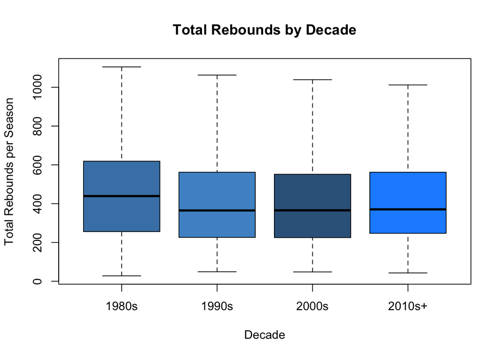

```r
boxplot(TRB ~ Decade, data = centers_clean,
        main = "Total Rebounds by Decade",
        xlab = "Decade", ylab = "Total Rebounds per Season",
        col = c("steelblue", "steelblue3", "steelblue4", "dodgerblue"),
        outline = FALSE)
```

```r
anova_reb <- aov(TRB ~ Decade, data = centers_clean)
summary(anova_reb)
```

```
##               Df    Sum Sq Mean Sq F value   Pr(>F)
## Decade         3   1047127  349042   6.513 0.000218 ***
## Residuals   2709 145171872   53589
## ---
## Signif. codes:  0 '***' 0.001 '**' 0.01 '*' 0.05 '.' 0.1 ' ' 1
```

```r
TukeyHSD(anova_reb)
```

```
##   Tukey multiple comparisons of means
##     95% family-wise confidence level
##
## Fit: aov(formula = TRB ~ Decade, data = centers_clean)
##
## $Decade
##                    diff        lwr        upr     p adj
## 1990s-1980s  -45.053738 -81.256068  -8.851409 0.0076109
## 2000s-1980s  -58.213206 -93.025833 -23.400580 0.0001047
## 2010s+-1980s -36.127080 -68.601676  -3.652484 0.0221875
## 2000s-1990s  -13.159468 -47.109739  20.790803 0.7514813
## 2010s+-1990s   8.926658 -22.621738  40.475054 0.8861672
## 2010s+-2000s  22.086126  -7.857348  52.029600 0.2299044
```

Rebounding differences across decades are worth interpreting carefully alongside the three-point and assists results — if rebounding has declined alongside increased perimeter responsibilities, that is evidence of a genuine positional tradeoff rather than simply an expansion of the center’s role.

## Principal Component Analysis

With over 40 statistical columns in the dataset, directly clustering on all variables would be noisy and computationally unstable. Principal component analysis reduces the dimensionality of the data by finding linear combinations of the original variables — principal components — that capture the most variance with the fewest dimensions.

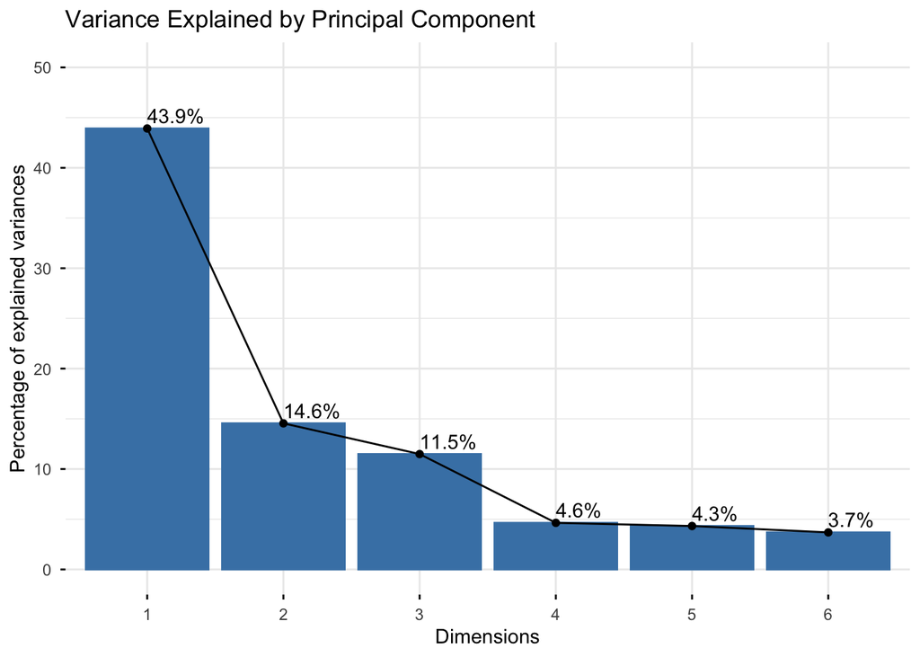

```r
# Select numerical columns for analysis
numerical_data <- centers_clean %>%
  select(Year, G, MP, starts_with("X3"), starts_with("X2"),
         FG., eFG., FT., TS., FTr, X3PAr, TOV.,
         AST, TRB, ORB, DRB, STL, BLK, TOV, PF, PTS,
         PER, OWS, DWS, WS, BPM, VORP, AP36)

# Run PCA with FactoMineR (integrates cleanly with clustering)
data.pca <- PCA(numerical_data, ncp = 6, graph = FALSE)

# Variance explained
fviz_eig(data.pca, addlabels = TRUE, ylim = c(0, 50),
         main = "Variance Explained by Principal Component")
```

```r
# Show cumulative variance for first 6 components
data.pca$eig[1:6, ]
```

```
##        eigenvalue percentage of variance cumulative percentage of variance
## comp 1  14.054195              43.919360                          43.91936
## comp 2   4.656327              14.551023                          58.47038
## comp 3   3.677112              11.490976                          69.96136
## comp 4   1.484718               4.639745                          74.60110
## comp 5   1.383773               4.324292                          78.92540
## comp 6   1.179959               3.687372                          82.61277
```

Six principal components were retained, explaining over 75% of the total variance in the dataset. The components have interpretable structure:

```r
# Display loadings for interpretation
data.pca$var$coord[, 1:6]
```

```
##             Dim.1       Dim.2        Dim.3        Dim.4       Dim.5       Dim.6
## Year   0.00871521  0.69847846 -0.001581713 -0.140236892 -0.05142955 -0.25486277
## G      0.57771281 -0.38751642 -0.002971739 -0.252316851  0.22122489  0.33022638
## MP     0.90870425 -0.27366451  0.081713002 -0.139769532  0.06811068  0.09489708
## X3P    0.17594939  0.53810497  0.687449706 -0.159694433  0.31472012  0.01940598
## X3PA   0.18507753  0.53548474  0.697463525 -0.157901468  0.30617922  0.01464216
## X3P.   0.13421906  0.38371468  0.404791712 -0.041346520  0.02627267  0.14913344
## X3PAr  0.01263949  0.59107071  0.641718800 -0.168355858  0.28477081  0.01453149
## X2P    0.90589562 -0.16958380  0.057734995 -0.038572993 -0.25039673  0.09027224
## X2PA   0.86455743 -0.27896443  0.138685977 -0.048041649 -0.26950414  0.09032258
## X2P.   0.39050804  0.71551635 -0.501342490 -0.028552031  0.07719174  0.16719341
## FG.    0.40190173  0.54424973 -0.687886324  0.015754995  0.00249757  0.16809627
## eFG.   0.40827148  0.71486758 -0.496775161 -0.034866628  0.08862389  0.17544514
## FT.    0.26185960  0.13513920  0.410116751  0.037501009 -0.36801937  0.44976202
## TS.    0.48056415  0.68416370 -0.432033862  0.018129676  0.01146169  0.28597665
## FTr    0.14136806 -0.02340213 -0.530981154  0.151541229  0.27929008 -0.05920181
## TOV.  -0.28348554 -0.27768583 -0.273348473  0.493771013  0.55979804  0.20323409
## AST    0.74580317 -0.01284644  0.344257056  0.489532495 -0.01769991  0.05010225
## TRB    0.91549003 -0.20586168 -0.050542427 -0.128181437  0.08145010 -0.05907630
## ORB    0.80733972 -0.26199099 -0.213114444 -0.196602568  0.04011186 -0.06714748
## DRB    0.91438952 -0.16995383  0.024228214 -0.090986111  0.09541103 -0.05233404
## STL    0.77197537 -0.16392501  0.150339060  0.108853740  0.08618391 -0.09713912
## BLK    0.65061473 -0.24090500 -0.111056516 -0.192869778  0.27180330 -0.26364080
## TOV    0.82843045 -0.31001446  0.085340469  0.145098617  0.05356282  0.22149225
## PF     0.68014974 -0.40661480 -0.017895696 -0.161569572  0.26064905  0.34090367
## PTS    0.91758539 -0.08235091  0.162186200 -0.044531279 -0.17550503  0.09096239
## PER    0.79354601  0.37435793 -0.081584516  0.013046309 -0.28616090 -0.16263013
## OWS    0.83507643  0.25235408 -0.114587569 -0.001612653 -0.20592185 -0.07007669
## DWS    0.84932888 -0.19412209 -0.009403181 -0.053900605  0.18042189 -0.23228702
## WS     0.93966991  0.08648420 -0.081557040 -0.025364093 -0.06100768 -0.14924507
## BPM    0.79713762  0.29317885 -0.046125460  0.225061166  0.09392866 -0.26805897
## VORP   0.86388020  0.11541306  0.028694914  0.227155641  0.06633398 -0.30789403
## AP36   0.39633195  0.19809368  0.406122782  0.720842035 -0.05011299  0.04179675
```

## Hierarchical Clustering

With the principal components in hand, hierarchical clustering was used to identify distinct center archetypes. Unlike k-means, hierarchical clustering does not require pre-specifying the number of clusters, instead building a full hierarchy that can be cut at any level. Ward’s criterion was used, which minimizes within-cluster variance and is well-suited to PCA-derived inputs.

The `HCPC` function from FactoMineR performs hierarchical clustering directly on PCA output, automatically determining the optimal cut point.

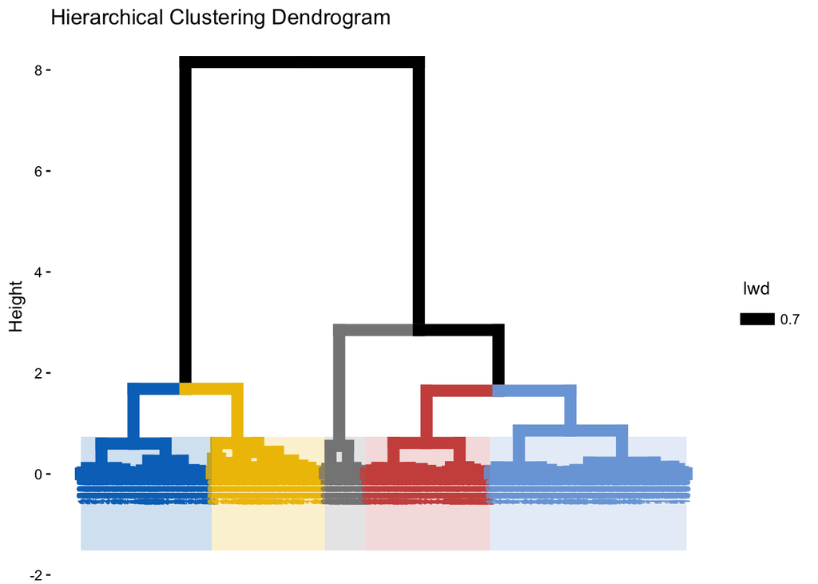

```r
# Hierarchical clustering on PCA components
res.hcpc <- HCPC(data.pca, graph = FALSE)

# Cluster dendrogram
fviz_dend(res.hcpc,
          cex = 0.5,
          palette = "jco",
          rect = TRUE, rect_fill = TRUE,
          rect_border = "jco",
          main = "Hierarchical Clustering Dendrogram")
```

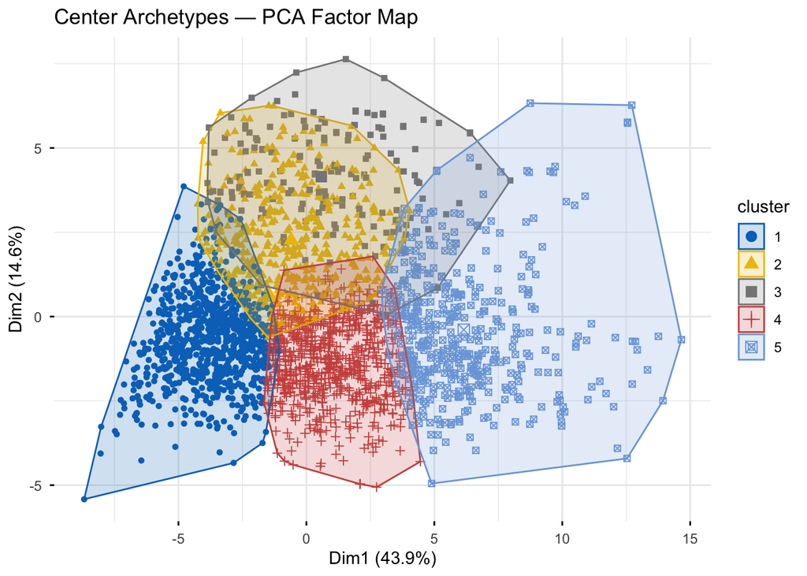

```r
# Cluster map on first two principal components
fviz_cluster(res.hcpc,
             repel = FALSE,
             geom = "point",
             pointsize = 1.5,
             show.clust.cent = TRUE,
             palette = "jco",
             ggtheme = theme_minimal(),
             main = "Center Archetypes — PCA Factor Map")
```

```r
# Variable contributions to each cluster
res.hcpc$desc.var$quanti
```

```
## $`1`
##           v.test Mean in category  Overall mean sd in category   Overall sd
## TOV.   13.062115       16.5433790   15.06634722     4.47405657   4.06648024
## FTr    -4.741514        0.3612112    0.38130704     0.15354442   0.15241640
## X3P.   -7.541893        0.0725137    0.11234279     0.18484332   0.18991636
## X3PAr  -7.702894        0.0195468    0.04220789     0.05517054   0.10579596
## X3P    -9.773502        1.1061644    7.12974567     4.18536354  22.16393641
## Year   -9.830004     1999.5958904 2003.04570586    10.19047731  12.62073038
## X3PA  -10.143317        4.6073059   21.58680428    13.74992375  60.19870588
## FT.   -10.766454        0.6441495    0.67841504     0.12581590   0.11445286
## AP36  -13.291100        1.4335341    1.83026758     0.71016775   1.07344617
## G     -21.322253       59.2500000   66.80575009    11.89107000  12.74344407
## BLK   -22.298071       36.6643836   72.29045337    29.05237219  57.45699885
## AST   -23.692630       34.8801370   82.92001474    22.46926908  72.91735913
## FG.   -25.055605        0.4592180    0.50470254     0.04687087   0.06528312
## STL   -25.821705       19.9189498   37.44084040    11.01613830  24.40272711
## PF    -26.048788      126.5890411  175.10873572    47.21743707  66.98427486
## VORP  -26.265475       -0.1762557    0.90106893     0.44548229   1.47503952
## TOV   -26.504436       48.6621005   91.95245116    23.52992804  58.73741873
## X2P.  -26.620288        0.4640308    0.51398120     0.04745332   0.06747896
## X2PA  -27.114800      219.9417808  453.54367858   113.90227542 309.82201653
## eFG.  -27.367709        0.4614658    0.51144268     0.04692715   0.06567097
## OWS   -27.945128        0.1777397    1.79985256     0.64335018   2.08745573
## DWS   -28.204267        0.9809361    2.03542204     0.49699052   1.34452322
## ORB   -29.009055       73.7100457  133.44305197    33.60674997  74.04966766
## X2P   -29.101447      102.2694064  234.69259123    53.55102995 163.64086389
## TS.   -29.377571        0.4962865    0.54622337     0.04615565   0.06112903
## PTS   -29.696662      257.5605023  615.16328787   131.99351285 433.04753162
## WS    -31.347600        1.1598174    3.83549576     0.83479249   3.06953040
## BPM   -31.410854       -3.0012557   -0.45993365     2.06584770   2.90952620
## DRB   -31.515120      140.8378995  287.23479543    59.73504075 167.05336107
## PER   -31.644271       10.7743151   14.87021747     2.84637318   4.65475487
## TRB   -31.930543      214.5479452  420.67784740    88.66181056 232.15444612
## MP    -32.975241      870.6095890 1525.12937707   341.07905336 713.80095270
##             p.value   n
## TOV.   5.420101e-39 876
## FTr    2.121266e-06 876
## X3P.   4.631968e-14 876
## X3PAr  1.330191e-14 876
## X3P    1.463058e-22 876
```

[output cut: 256 more lines]

```
## STL   3.434424e-185 443
## BLK   1.782005e-122 443
## PF     1.015330e-82 443
## AP36   3.948583e-61 443
## G      5.515794e-58 443
## TS.    1.328281e-39 443
## FG.    2.485811e-30 443
## eFG.   7.414177e-25 443
## X2P.   2.757694e-23 443
## FTr    1.554452e-16 443
## FT.    8.704162e-13 443
## X3P.   1.996824e-04 443
## Year   2.161530e-02 443
## X3PAr  8.887936e-05 443
## TOV.   8.800564e-17 443
```

```r
# Which principal components define each cluster
res.hcpc$desc.axes$quanti
```

```
## $`1`
##           v.test Mean in category  Overall mean sd in category Overall sd
## Dim.4   5.556303        0.1882633  5.643763e-13      0.8902041   1.218490
## Dim.3   4.437302        0.2366084 -3.397168e-13      1.1516686   1.917580
## Dim.5  -3.898037       -0.1275076  3.269358e-13      1.0420970   1.176339
## Dim.6  -7.263717       -0.2194068  1.546608e-12      1.0043329   1.086259
## Dim.2 -11.350358       -0.6810657 -1.133084e-12      1.2953406   2.157852
## Dim.1 -35.945753       -3.7472120  4.765193e-13      1.3820455   3.748893
##             p.value   n
## Dim.4  2.755478e-08 876
## Dim.3  9.109351e-06 876
## Dim.5  9.697540e-05 876
## Dim.6  3.765951e-13 876
## Dim.2  7.385932e-30 876
## Dim.1 5.896888e-283 876
##
## $`2`
##           v.test Mean in category  Overall mean sd in category Overall sd
## Dim.2  25.052291        2.2677233 -1.133084e-12      1.4674207   2.157852
## Dim.6   2.907656        0.1324943  1.546608e-12      0.8882698   1.086259
## Dim.1  -3.764301       -0.5919815  4.765193e-13      1.7800440   3.748893
## Dim.3 -24.679338       -1.9852163 -3.397168e-13      1.2143923   1.917580
##             p.value   n
## Dim.2 1.648335e-138 470
## Dim.6  3.641489e-03 470
## Dim.1  1.670158e-04 470
## Dim.3 1.782722e-134 470
##
## $`3`
##          v.test Mean in category  Overall mean sd in category Overall sd
## Dim.3 30.253832        4.2685739 -3.397168e-13       1.739216   1.917580
## Dim.2 26.127425        4.1482730 -1.133084e-12       1.384617   2.157852
## Dim.5 14.978270        1.2964121  3.269358e-13       1.127073   1.176339
## Dim.1  2.118241        0.5842884  4.765193e-13       2.591718   3.748893
## Dim.4 -9.592940       -0.8600481  5.643763e-13       1.476364   1.218490
##             p.value   n
## Dim.3 4.645645e-201 173
## Dim.2 1.779525e-150 173
## Dim.5  1.018335e-50 173
## Dim.1  3.415468e-02 173
```

[output cut: 14 more lines]

```
## Dim.2 2.843772e-90 751
##
## $`5`
##          v.test Mean in category  Overall mean sd in category Overall sd
## Dim.1 37.748262        6.1512896  4.765193e-13       2.234564   3.748893
## Dim.4  7.183733        0.3804858  5.643763e-13       1.632153   1.218490
## Dim.2 -4.175744       -0.3916714 -1.133084e-12       1.892309   2.157852
## Dim.5 -6.034158       -0.3085428  3.269358e-13       1.273505   1.176339
## Dim.6 -8.413013       -0.3972385  1.546608e-12       1.294228   1.086259
##             p.value   n
## Dim.1 8.032381e-312 443
## Dim.4  6.783308e-13 443
## Dim.2  2.970137e-05 443
## Dim.5  1.597932e-09 443
## Dim.6  3.996090e-17 443
```

```r
# Cluster membership counts
table(res.hcpc$data.clust$clust)
```

```
##
##   1   2   3   4   5
## 876 470 173 751 443
```

```r
# Add cluster assignments back to the main dataset
centers_clean$Cluster <- res.hcpc$data.clust$clust

# Average year by cluster — shows temporal distribution
centers_clean %>%
  group_by(Cluster) %>%
  summarise(
    avg_year    = round(mean(Year), 1),
    avg_3pa     = round(mean(X3PA), 2),
    avg_trb     = round(mean(TRB), 1),
    avg_blk     = round(mean(BLK), 1),
    avg_pts     = round(mean(PTS), 1),
    n           = n()
  )
```

```
## # A tibble: 5 × 7
##   Cluster avg_year avg_3pa avg_trb avg_blk avg_pts     n
##   <fct>      <dbl>   <dbl>   <dbl>   <dbl>   <dbl> <int>
## 1 1          2000.    4.61    214.    36.7    258.   876
## 2 2          2014.    7.95    343.    59.2    433.   470
## 3 3          2018.  208.      371.    60.3    737    173
## 4 4          1998.    5.45    512.    90.1    711.   751
## 5 5          2002.   24.1     774.   131.    1306.   443
```

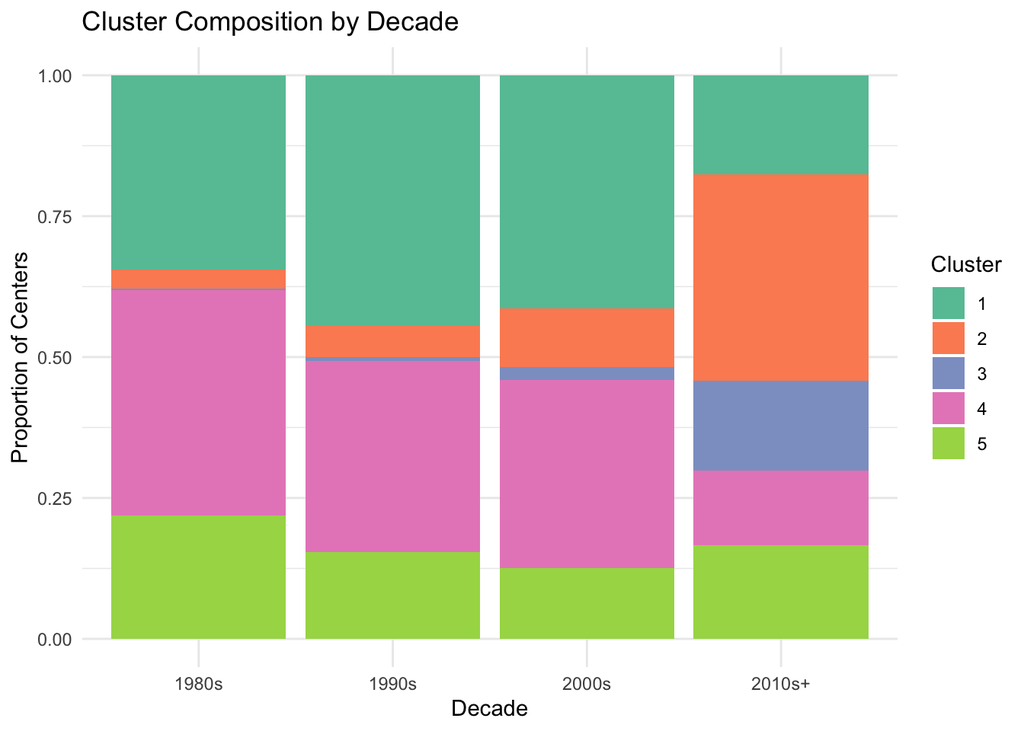

```r
# Proportion of each cluster by decade
cluster_by_decade <- centers_clean %>%
  group_by(Decade, Cluster) %>%
  summarise(n = n()) %>%
  group_by(Decade) %>%
  mutate(prop = n / sum(n))

ggplot(cluster_by_decade, aes(x = Decade, y = prop, fill = factor(Cluster))) +
  geom_col(position = "stack") +
  scale_fill_brewer(palette = "Set2", name = "Cluster") +
  labs(title = "Cluster Composition by Decade",
       x = "Decade", y = "Proportion of Centers") +
  theme_minimal()
```

## ARIMA Time Series Forecasting

The cluster analysis established that the center position has shifted toward scoring and three-point shooting archetypes. But is this an ongoing trend, or has it already plateaued? Rather than forecasting raw statistics, we track the proportion of centers belonging to each archetype cluster per year, and fit ARIMA models to those proportions to project where the position composition is headed.

```r
# Compute proportion of centers in each cluster per year
cluster_props <- centers_clean %>%
  group_by(Year, Cluster) %>%
  summarise(n = n(), .groups = "drop") %>%
  group_by(Year) %>%
  mutate(prop = n / sum(n)) %>%
  ungroup()
```

### Scoring Cluster (Cluster 2)

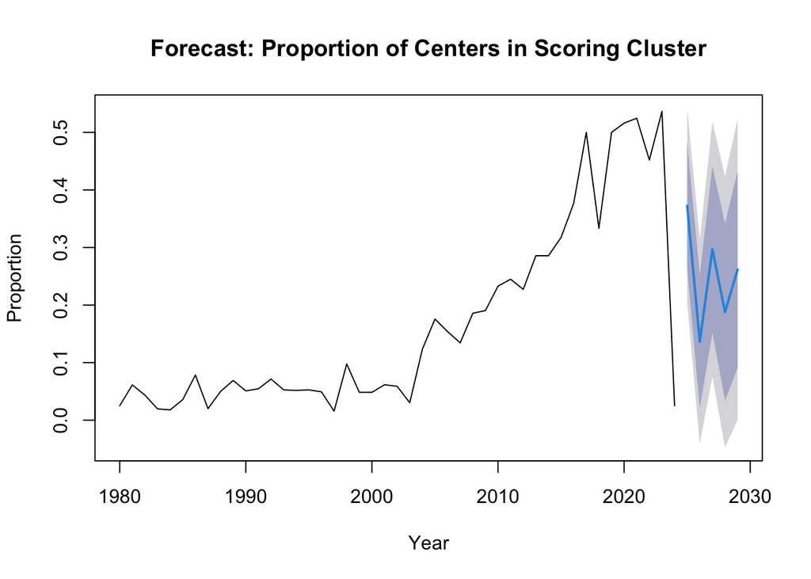

```r
props_c2 <- cluster_props %>% filter(Cluster == 2)

ts_c2 <- ts(props_c2$prop,
            start = min(props_c2$Year),
            end   = max(props_c2$Year),
            frequency = 1)

arima_c2 <- auto.arima(ts_c2)
forecast_c2 <- forecast(arima_c2, h = 5)

plot(forecast_c2,
     main = "Forecast: Proportion of Centers in Scoring Cluster",
     xlab = "Year", ylab = "Proportion")
```

```r
print(forecast_c2)
```

```
##      Point Forecast      Lo 80     Hi 80         Lo 95     Hi 95
## 2025      0.3724782 0.26195535 0.4830010  2.034481e-01 0.5415083
## 2026      0.1364646 0.02039453 0.2525347 -4.104926e-02 0.3139785
## 2027      0.2967694 0.15204727 0.4414915  7.543601e-02 0.5181028
## 2028      0.1878874 0.03417098 0.3416039 -4.720160e-02 0.4229765
## 2029      0.2618421 0.09065865 0.4330255  3.963222e-05 0.5236445
```

### Three-Point Shooting Cluster (Cluster 3)

The three-point shooting cluster is the most recent archetype to emerge, with no members prior to 1989 and an average membership year of 2017.

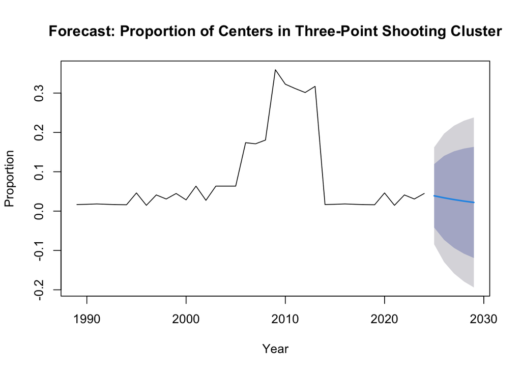

```r
props_c3 <- cluster_props %>% filter(Cluster == 3)

ts_c3 <- ts(props_c3$prop,
            start = min(props_c3$Year),
            end   = max(props_c3$Year),
            frequency = 1)

arima_c3 <- auto.arima(ts_c3)
forecast_c3 <- forecast(arima_c3, h = 5)

plot(forecast_c3,
     main = "Forecast: Proportion of Centers in Three-Point Shooting Cluster",
     xlab = "Year", ylab = "Proportion")
```

```r
print(forecast_c3)
```

```
##      Point Forecast       Lo 80     Hi 80       Lo 95     Hi 95
## 2025     0.03885607 -0.04175607 0.1194682 -0.08442955 0.1621417
## 2026     0.03371874 -0.07301404 0.1404515 -0.12951496 0.1969524
## 2027     0.02926064 -0.09352779 0.1520491 -0.15852806 0.2170493
## 2028     0.02539196 -0.10821971 0.1590036 -0.17894946 0.2297334
## 2029     0.02203478 -0.11918087 0.1632504 -0.19393591 0.2380055
```

### Defensive/Rebounding Cluster (Cluster 4)

The traditional defensive and rebounding cluster, most prevalent in the 1980s, has been declining. The forecast projects whether this decline continues.

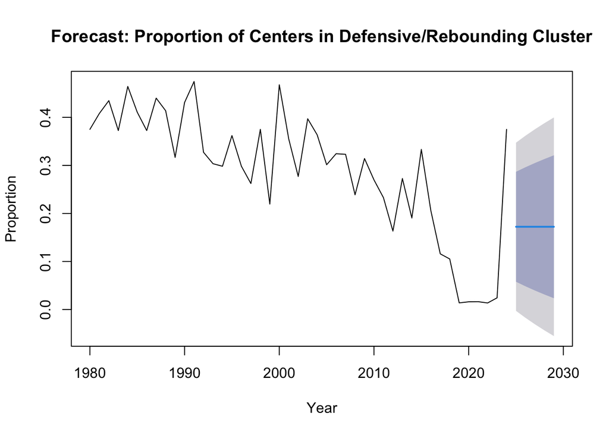

```r
props_c4 <- cluster_props %>% filter(Cluster == 4)

ts_c4 <- ts(props_c4$prop,
            start = min(props_c4$Year),
            end   = max(props_c4$Year),
            frequency = 1)

arima_c4 <- auto.arima(ts_c4)
forecast_c4 <- forecast(arima_c4, h = 5)

plot(forecast_c4,
     main = "Forecast: Proportion of Centers in Defensive/Rebounding Cluster",
     xlab = "Year", ylab = "Proportion")
```

```r
print(forecast_c4)
```

```
##      Point Forecast      Lo 80     Hi 80        Lo 95     Hi 95
## 2025       0.172302 0.05786257 0.2867413 -0.002717977 0.3473219
## 2026       0.172302 0.04838949 0.2962144 -0.017205814 0.3618097
## 2027       0.172302 0.03959089 0.3050130 -0.030662111 0.3752660
## 2028       0.172302 0.03134042 0.3132635 -0.043280117 0.3878840
## 2029       0.172302 0.02354684 0.3210571 -0.055199358 0.3998033
```

## Conclusions

The statistical evidence confirms what the eye test suggests: the center position has undergone a genuine and significant transformation since 1980.

The ANOVA results show that nearly every statistic differed significantly across decades, with three-point attempts and assists per 36 minutes rising substantially in the current era while traditional defensive metrics have shifted. The hierarchical clustering identified five distinct center archetypes, with scoring-focused and three-point shooting clusters now comprising the majority of the league, and the traditional rebounding-dominant cluster increasingly rare in recent seasons.

**Limitations and future directions:**

- This analysis uses season averages, which may obscure within-season variation and role changes
- Clustering on PCA components produces stable but sometimes hard-to-interpret archetypes; alternative methods (DBSCAN, Gaussian mixture models) could provide complementary insights
- A Markov chain transition framework would allow examination of how individual players move between archetypes over their careers, which is a natural extension of this work
- Examining how cluster membership correlates with team success would address the practical question of which type of center actually wins games

## Data and Reproducibility

Data was downloaded from [Basketball Reference](https://www.basketball-reference.com/) season totals pages. To reproduce this analysis, download the season averages data and save it as `season_stats.csv` in the same directory as this `.Rmd` file.

**Required packages:** `dplyr`, `ggplot2`, `factoextra`, `FactoMineR`, `cluster`, `forecast`

Install all at once with:

```r
install.packages(c("dplyr", "ggplot2", "factoextra", "FactoMineR", "cluster", "forecast"))
```